# 01.1: Digitizing Landmarks in StereoMorph

```r
shapes <- readShapes("example.digitized")

# curves include eye, head, tail 1, tail end, tail 2, anal fin,
# pectoral fin, opercle, pre-opercle
curves.list <- c(20, 24, 24, 16, 12, 8, 8, 24, 16)
```

Then use `readland.shapes` to read the data into a useable format for **geomorph**.

```r
shapesGM <- readland.shapes(shapes, nCurvePts = curves.list)
```

Every curve needs to have at least three landmarks (or it is not a curve). Other than that, one can vary the number for every curve. The set chosen is hypothetical. Let’s see what it looks like following generalized Procrustes Analysis (GPA).

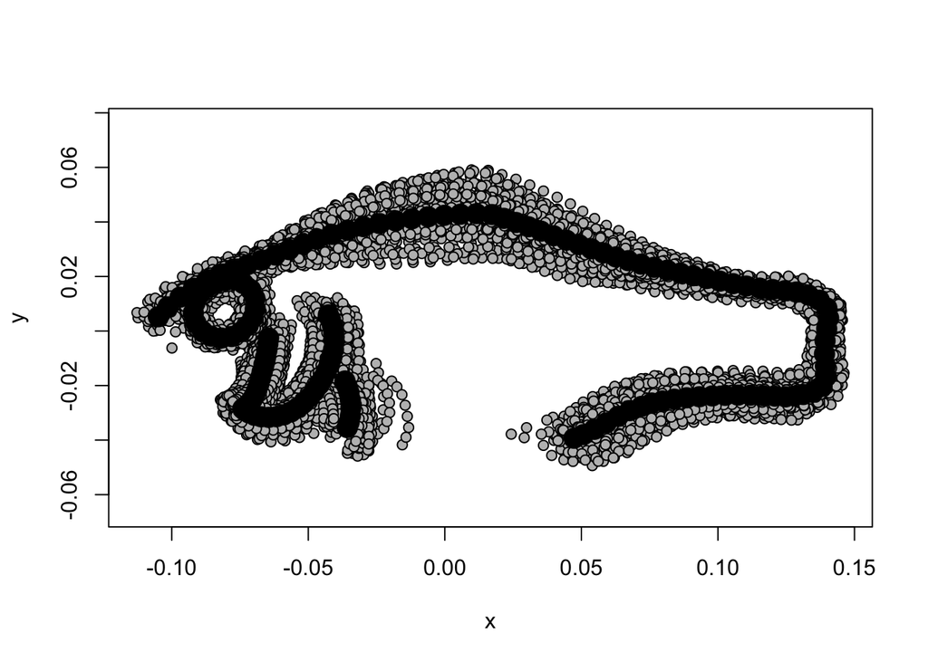

```r
Y.gpa <- gpagen(shapesGM, print.progress = FALSE)
plot(Y.gpa)
```

The density of semilandmarks might be a little too great. We can reduce it by 50%, for example, in one line of code:

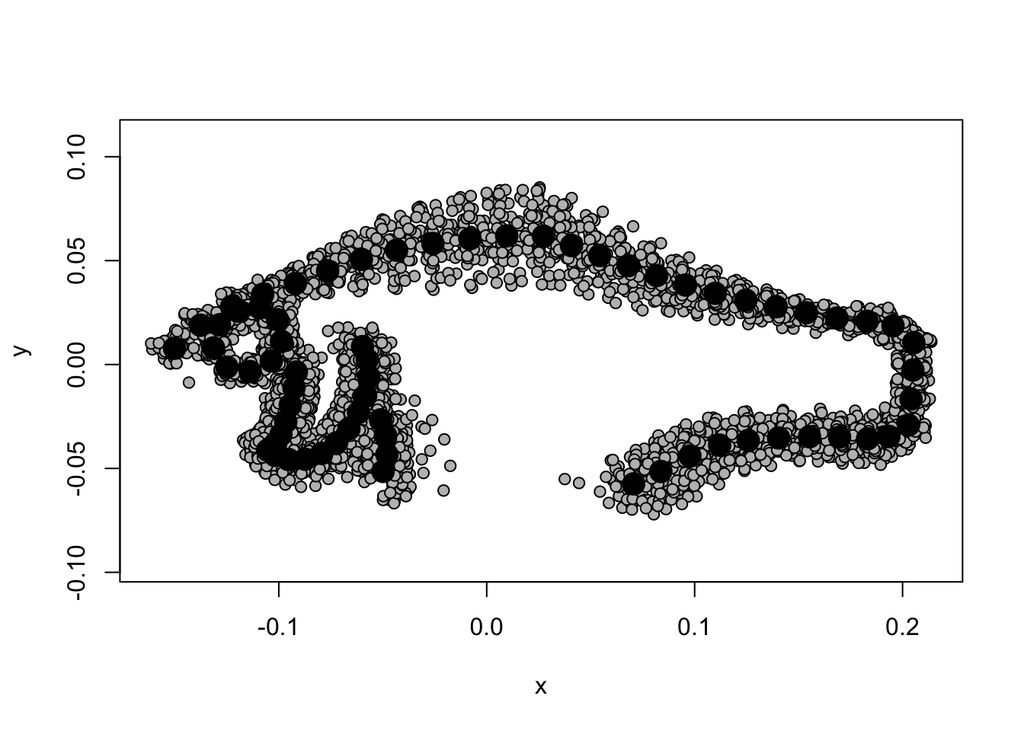

```r
shapesGM <- readland.shapes(shapes, nCurvePts = 0.5 * curves.list)
Y.gpa <- gpagen(shapesGM, print.progress = FALSE)
plot(Y.gpa)
```

Later it might impress you that no arguments for gpagen are needed when reading data in with `readland.shapes`. Class `geomorphShapes` objects also have various attributes that can be exported for other uses.

```r
class(shapesGM)
```

```
## [1] "geomorphShapes"
```

```r
attributes(shapesGM)
```

```
## $names
## [1] "landmarks" "fixed"     "sliders"   "curves"    "n"         "p"
## [7] "k"         "scaled"
##
## $class
## [1] "geomorphShapes"
```

```r
shapesGM$fixed # which landmakrs are fixed
```

```
##  [1]  1  2  3  4  5  6  7  8  9 10 11 12
```

```r
shapesGM$curves # a curves matrix for gpagen - can be modified
```

```
##            [,1] [,2] [,3]
## curveLM.13   12   13   14
## curveLM.14   13   14   15
## curveLM.15   14   15   16
## curveLM.16   15   16   17
## curveLM.17   16   17   18
## curveLM.18   17   18   19
## curveLM.19   18   19   20
## curveLM.20   19   20   12
## curveLM.21    1   21   22
## curveLM.22   21   22   23
## curveLM.23   22   23   24
## curveLM.24   23   24   25
## curveLM.25   24   25   26
## curveLM.26   25   26   27
## curveLM.27   26   27   28
## curveLM.28   27   28   29
## curveLM.29   28   29   30
## curveLM.30   29   30    2
## curveLM.31    2   31   32
## curveLM.32   31   32   33
## curveLM.33   32   33   34
## curveLM.34   33   34   35
## curveLM.35   34   35   36
## curveLM.36   35   36   37
## curveLM.37   36   37   38
## curveLM.38   37   38   39
## curveLM.39   38   39   40
## curveLM.40   39   40    3
## curveLM.41    3   41   42
## curveLM.42   41   42   43
## curveLM.43   42   43   44
## curveLM.44   43   44   45
## curveLM.45   44   45   46
## curveLM.46   45   46    4
## curveLM.47    4   47   48
## curveLM.48   47   48   49
## curveLM.49   48   49   50
## curveLM.50   49   50    5
## curveLM.51    5   51   52
## curveLM.52   51   52    6
## curveLM.53    7   53   54
## curveLM.54   53   54    8
## curveLM.55    9   55   56
## curveLM.56   55   56   57
## curveLM.57   56   57   58
## curveLM.58   57   58   59
## curveLM.59   58   59   60
## curveLM.60   59   60   61
## curveLM.61   60   61   62
## curveLM.62   61   62   63
## curveLM.63   62   63   64
## curveLM.64   63   64   10
## curveLM.65   11   65   66
## curveLM.66   65   66   67
## curveLM.67   66   67   68
## curveLM.68   67   68   69
## curveLM.69   68   69   70
## curveLM.70   69   70   10
```

```r
shapesGM$landmarks[[1]] # specimen 1
```

```
##                [,1]      [,2]
## LM1        59.10605 -41.32745
## LM2        74.27244 -37.38964
## LM3        87.95729 -38.09143
## LM4        88.15223 -41.52239
## LM5        81.21233 -42.26316
## LM6        77.97632 -44.09561
## LM7        66.82570 -42.73102
## LM8        67.29356 -44.29055
## LM9        66.16291 -40.78161
## LM10       63.74564 -44.56347
## LM11       64.01856 -40.70364
## LM12       62.80992 -39.37804
## curveLM.13 63.35576 -40.20925
## curveLM.14 63.23879 -41.18580
## curveLM.15 62.56849 -41.91977
## curveLM.16 61.58884 -42.10721
## curveLM.17 60.79722 -41.57606
## curveLM.18 60.50962 -40.63789
## curveLM.19 60.90162 -39.76580
## curveLM.20 61.76877 -39.41703
## curveLM.21 60.09664 -40.23578
## curveLM.22 61.23111 -39.43632
## curveLM.23 62.59470 -38.96945
## curveLM.24 64.00739 -38.67625
## curveLM.25 65.44277 -38.38270
## curveLM.26 66.87240 -38.13042
## curveLM.27 68.38092 -38.01345
## curveLM.28 69.85046 -37.93548
## curveLM.29 71.32668 -37.74054
## curveLM.30 72.78007 -37.54560
## curveLM.31 75.48816 -37.55269
## curveLM.32 76.68105 -37.77086
## curveLM.33 77.89008 -38.00519
## curveLM.34 79.15621 -38.10168
## curveLM.35 80.41810 -38.20840
## curveLM.36 81.69189 -38.28637
## curveLM.37 82.98184 -38.24738
## curveLM.38 84.20719 -38.44232
## curveLM.39 85.39355 -38.20840
```

[output cut: 16 more lines]

```
## curveLM.56 66.16291 -41.79002
## curveLM.57 66.08580 -42.26229
## curveLM.58 66.00695 -42.73384
## curveLM.59 65.85100 -43.15060
## curveLM.60 65.63888 -43.56695
## curveLM.61 65.39263 -43.96915
## curveLM.62 65.06841 -44.29338
## curveLM.63 64.68945 -44.48549
## curveLM.64 64.23370 -44.60245
## curveLM.65 64.01856 -41.28233
## curveLM.66 64.01856 -41.86102
## curveLM.67 63.97957 -42.42357
## curveLM.68 63.94058 -42.98611
## curveLM.69 63.90159 -43.52582
## curveLM.70 63.86260 -44.08836
```

```r
names(shapesGM$landmarks) # all specimen names
```

```
##  [1] "P1000602" "P1000603" "P1000604" "P1000605" "P1000606" "P1000615"
##  [7] "P1000616" "P1000617" "P1000618" "P1000619" "P1000647" "P1000648"
## [13] "P1000649" "P1000650" "P1000651" "P1000657" "P1000658" "P1000659"
## [19] "P1000660" "P1000661" "P1000670" "P1000671" "P1000672" "P1000673"
## [25] "P1000674" "P1000684" "P1000685" "P1000686" "P1000687" "P1000688"
## [31] "P1000696" "P1000697" "P1000698" "P1000699" "P1000700" "P1000708"
## [37] "P1000709" "P1000710" "P1000711" "P1000712" "P1000719" "P1000720"
## [43] "P1000721" "P1000722" "P1000723" "P1000731" "P1000732" "P1000733"
## [49] "P1000734" "P1000735" "P1000743" "P1000744" "P1000745" "P1000746"
## [55] "P1000747" "P1000755" "P1000756" "P1000757" "P1000758" "P1000759"
```